# Recorded violence in Myanmar

Township patterns · January 2021–September 2025

Davin Cuaso · ISSS626 Take-home Exercise 2

2026-10-03

## What the analysis asks

Where do high recorded counts cluster, which townships differ from their neighbours, and how do those patterns change?

- **Frequency:** retained violence events.
- **Reported severity:** fatalities attached to those events.
- **Time:** 57 monthly observations per township.

The maps describe recorded burden. They do not estimate individual risk or current conditions.

## From source records to a complete cube

**87,109** source records → **53,899** retained events.

330 townships × 57 months = **18,810 bins**.

Three event types: battles, explosions/remote violence, violence against civilians.

Checks cover duplicate IDs, dates, coordinates, fatality values, boundary version and unique spatial matches.

Precision-3 locations are excluded. Eight eligible points lack a unique township match.

Zero bins mean no retained event was recorded.

## November 2023 has the largest monthly event count

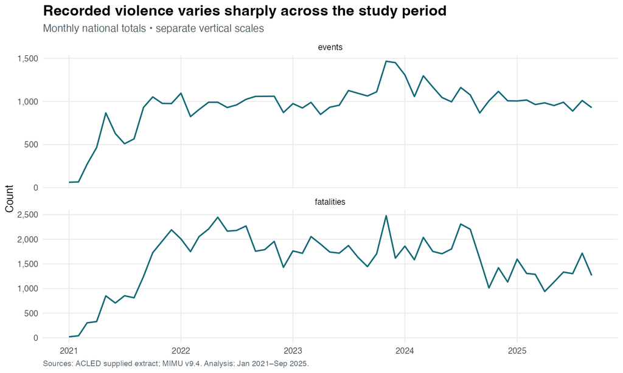

**1,466 events** in November 2023. Fatality peaks do not always match event peaks.

## Event hot spots concentrate in several regions

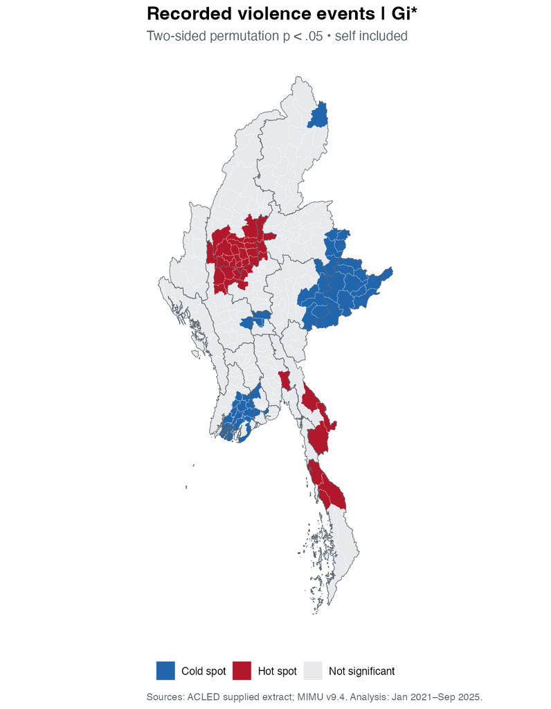

**38 hot spots**, including:

- Sagaing: 18
- Mandalay: 7
- Magway: 6

Queen neighbours, self included; two-sided permutation p < .05.

A grey township has insufficient evidence under this test. It is not necessarily safe.

## Fatality concentrations differ from event frequency

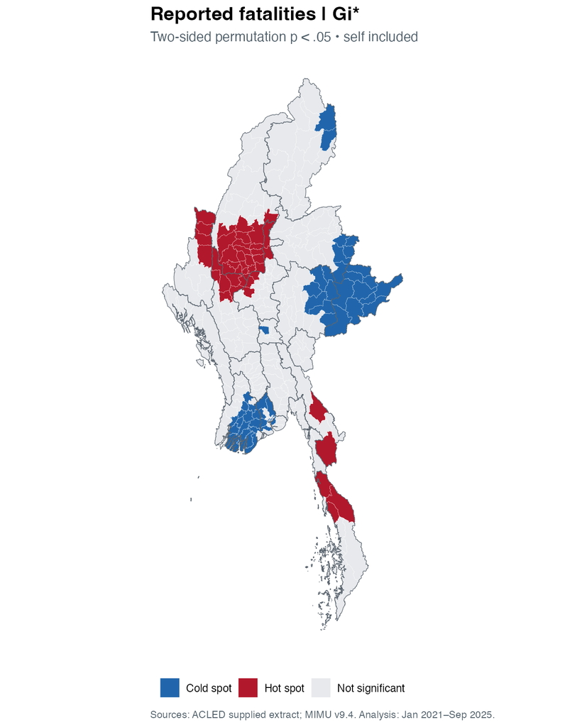

**43 reported-fatality hot spots.**

Chin contains four, but no event-count hot spot under the same specification.

Kale has the highest retained fatality total: **1,877**.

Reported totals have measurement uncertainty and can be influenced by severe incidents.

## Emerging patterns need both space and time

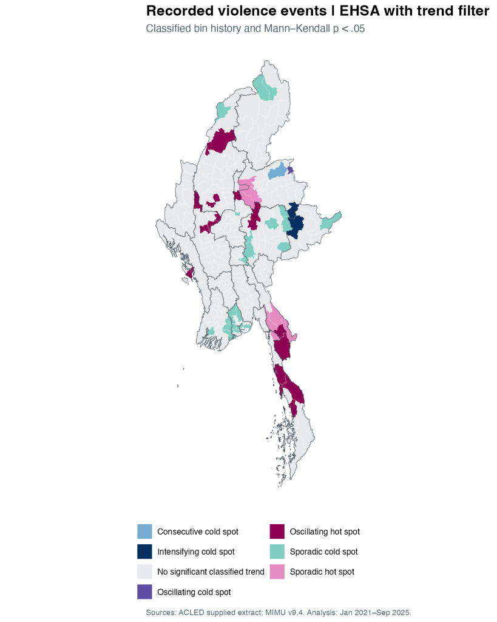

Each bin uses its township and neighbours at **t and t−1**.

Gi* → monthly history → Mann–Kendall trend → EHSA class.

66 townships have a recognised event history and p < .05 for the trend.

The full-history maps also retain patterns without a significant trend.

## A single label can hide many hot months

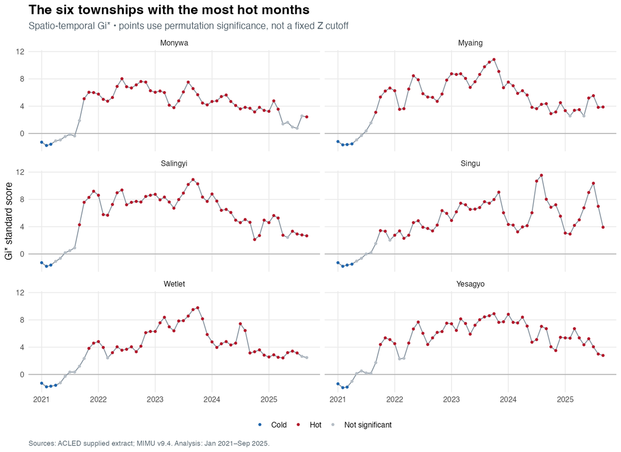

**Wetlet: 44 hot months**, yet no named endpoint pattern. Read the history beside the label.

## Twenty-seven hot spots survive both checks

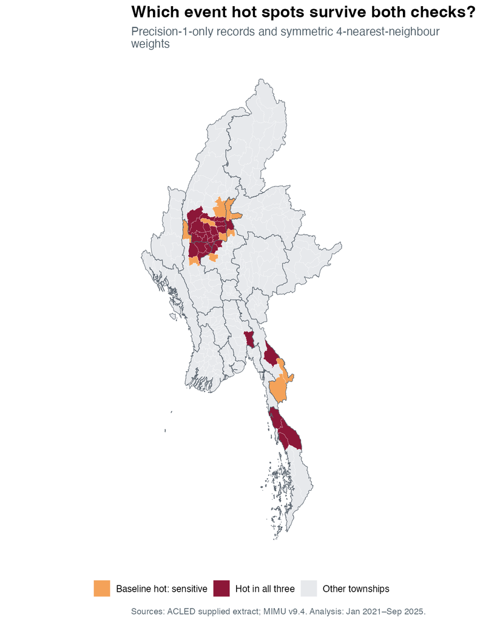

Starting with **38** event hot spots:

- **35** remain using precision-1 records only.
- **28** remain using symmetric four-nearest neighbours.
- **27** remain under both choices.

Eleven baseline hot spots depend on at least one tested assumption.

## The centre shifts mainly south

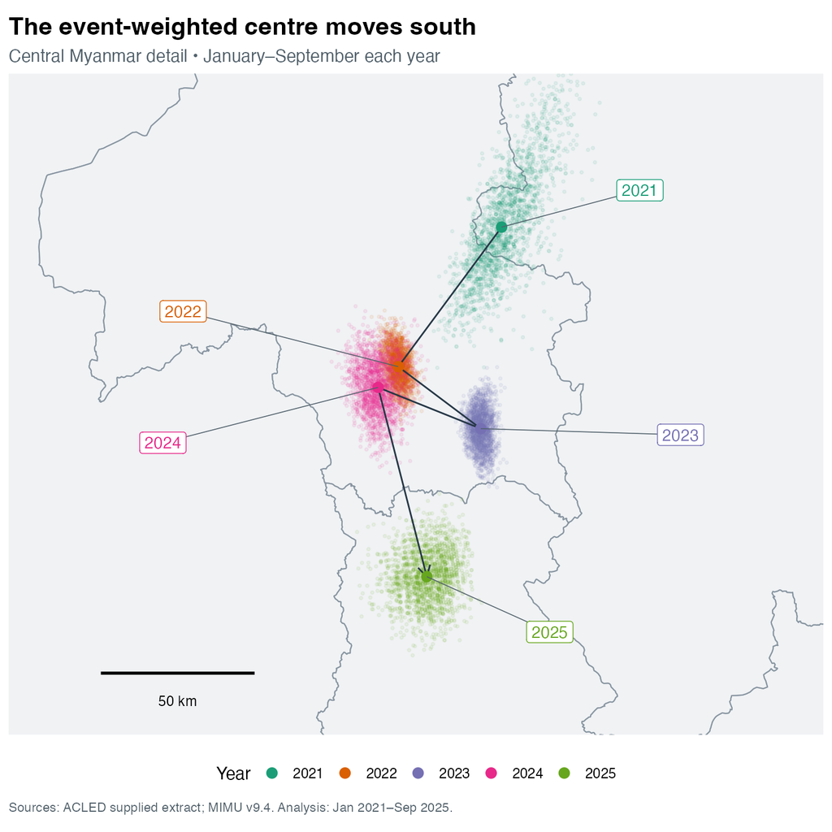

Comparable **January–September** windows.

2021 → 2025 displacement: **116 km**.

About 114 km south and 24 km west in the study projection.

Month-resampling range: **82–164 km**.

This describes the spatial balance of recorded events, not a moving front.

## Use the maps to guide further review

Start with the **27 robust event hot spots**, then assess local needs and reported severity.

- Check sensitive classifications against better location information.
- Keep historical burden separate from present conditions.
- Do not treat cold spots as places with no need.
- Trend tests are exploratory: reporting, multiplicity and serial dependence matter.

Submission hub · Technical report · [ACLED definitions](https://acleddata.com/methodology/acled-codebook) · [MIMU boundaries](https://geonode.themimu.info/layers/geonode%3Ammr_polbnda_adm3_250k_mimu_1)